# Szkolnictwo muzyczne w PL

Tomasz Przechlewski

April, 2019

Plik powiatyBySzkolyT.csv to zestawienie 380 powiatów w PL ze względu na: ppp – liczbę ludności w wieku przedprodukcyjnym (0–17 lat); totalp – łączną liczbę ludności; ppp.p – udział ludności w wieku przedprodukcyjnym w łącznej liczbie ludności (w procentach); OSM1/OSM2 – liczbę szkół muzycznych pierwszego i drugiego stopnia; SM1/SM2 – liczbę szkół muzycznych pierwszego i drugiego stopnia; L1/L2 – odpowiednio OSM1+SM1 oraz OSM2+SM2; typ – typ powiaty (m – miasto na prawach powiatu, p – “zwykły” powiat)

Dane dotyczące szkół zostały pobrane z rejestru https://rspo.men.gov.pl/. Dane dotyczące ludności (za rok 2017) z banku danych lokalnych

```r
library(ggplot2)
options(scipen=999)
options(digits = 2)

d <- read.csv("powiatyBySzkolyT.csv", sep = ';',  header=T, na.string="NA", colClasses=c("teryt"="character"));
razemS <- sum(d$SM1) + sum(d$SM2) +sum(d$OSM1) + sum(d$OSM2)
```

Liczba szkół wg rodzaju: SM1 = 498 (68.88) SM2 = 143 (19.78) OSM1 = 49 (6.78) OSM2 = 33 (4.56). Poniższa mapa przedstawia lokalizację wszystkich szkół muzycznych w Polsce:

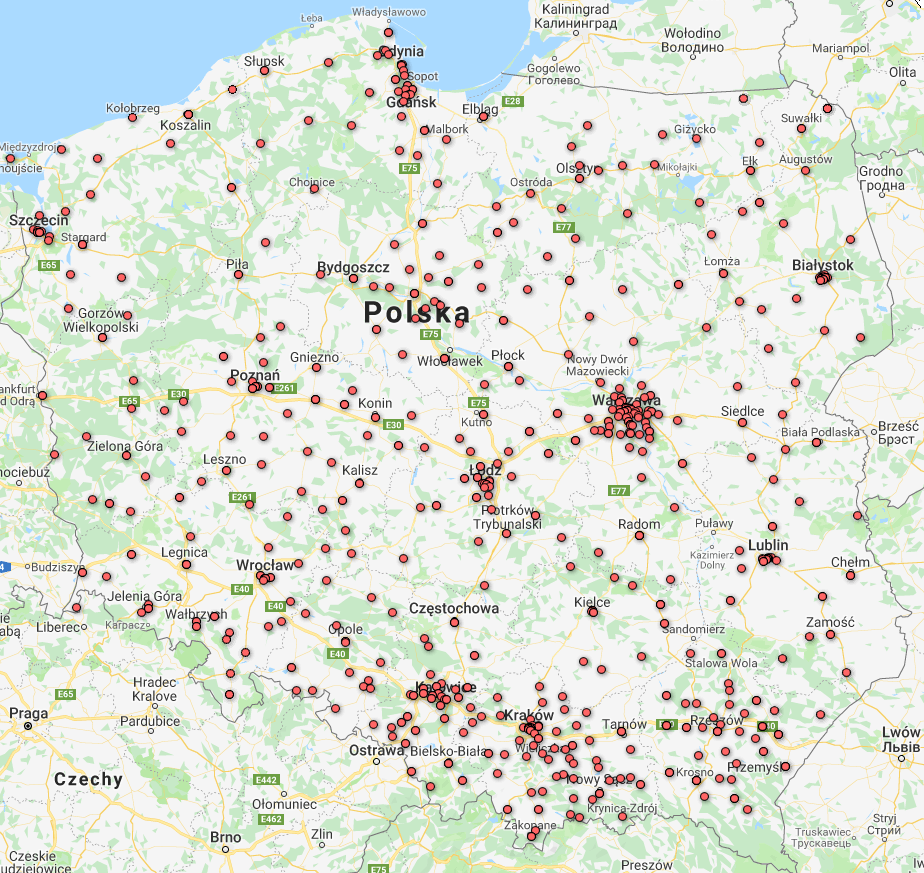

Szkoły koncentrują się w dużych aglomeracjach miejskich co jest zrozumiałe. Względny brak szkół w pasie Gorzów Wlk-Piła-Chojnice wynika zapewne z małego zaludnienia tej części Polski.

```r
total <- d$L1 + d$L2;
d["total"] <- total;
fivenum(d$total)
```

```
## [1]  0  1  1  2 43
```

```r
powiatyA <- nrow(d)
powiatyA # powinno być 380
```

```
## [1] 380
```

```r
pop.total <- sum(d$ppp)
```

Łączna liczba szkół 723. Średnio w powiecie jest 1.9 szkoły (mediana 1). Średnia liczba osób w wieku przedprodukcyjnym w powiecie 18212.24 (łącznie 6920652 osób).

## Porównanie województw

Kod TERYT województwa to dwie pierwsze litery kodu powiatu:

```r
woj <- substr(d$teryt, 1,2)
d["woj"] <- woj;
```

Porówanie rozkładów szkół muzycznych w województwach przy pomocy wykresu podełkowego

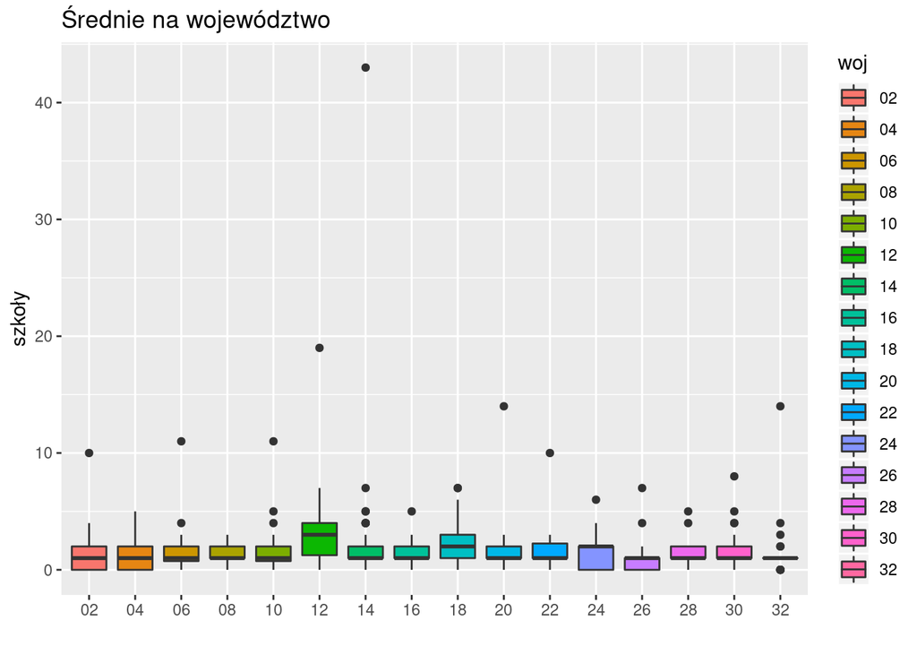

```r
ggplot(d, aes(x=woj, y=total, fill=woj)) + geom_boxplot() + ylab("szkoły") + xlab("") + ggtitle("Średnie na województwo");
```

Średnie dla województw:

```r
aggregate(total~woj, data=d, mean)
```

| woj | total |
| --- | --- |
| 02 | 1.5 |
| 04 | 1.4 |
| 06 | 1.6 |
| 08 | 1.3 |
| 10 | 1.8 |
| 12 | 3.8 |
| 14 | 2.7 |
| 16 | 1.6 |
| 18 | 2.5 |
| 20 | 2.1 |

[output cut: 6 more lines]

Wykres

[figure not shown]

```r
ggplot(d, aes(woj)) + geom_bar(aes(fill=woj)) +
coord_flip() + ggtitle("Liczba szkół")
```

## Porównanie powiatów

Histogram rozkładu liczby szkół:

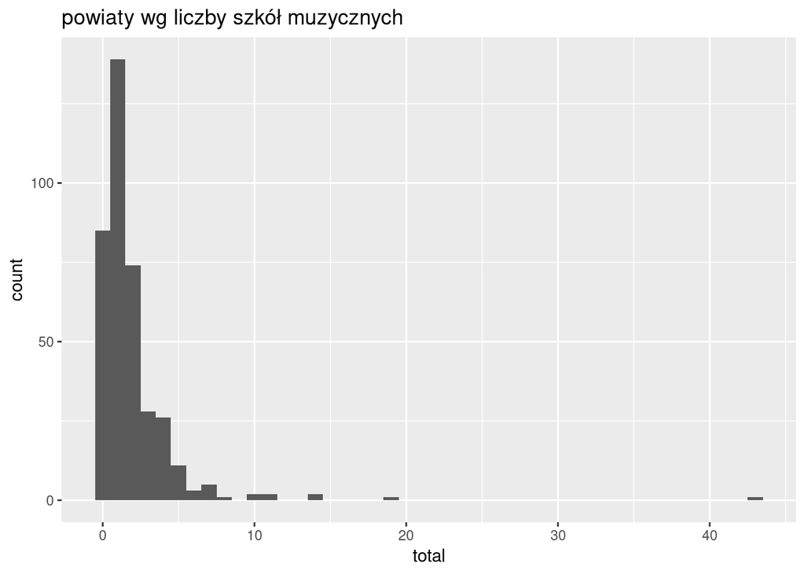

```r
ggplot(d, aes(x = total)) + geom_histogram(binwidth = 1) +
ggtitle("powiaty wg liczby szkół muzycznych")
```

```r
table(d$total)
```

```
##
##   0   1   2   3   4   5   6   7   8  10  11  14  19  43
##  85 139  74  28  26  11   3   5   1   2   2   2   1   1
```

## Tylko powiaty ze szkołami

Ile powiatów nie ma szkół muzycznych?

```r
do <- d;
d <- subset (d, total > 0);
powiatyS <- nrow(d)

powiatyS # powiaty ze szkołami
```

```
## [1] 295
```

```r
powiatyA - powiatyS # powiaty bez szkół
```

```
## [1] 85
```

```r
pppDens <- d$ppp/d$total
d["pppd"] <- pppDens
fivenum(d$pppd);
```

```
## [1]  1103  6220  8648 12782 39378
```

```r
mean(d$pppd);
```

```
## [1] 10085
```

Powiaty wg wartości UPP (mapa tematyczna):

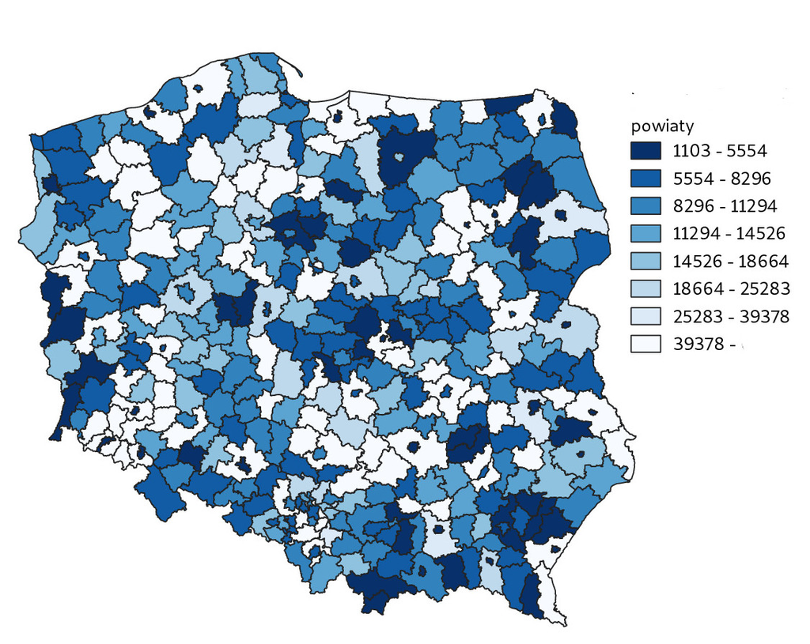

Rozkłady gęstości UPP według województw:

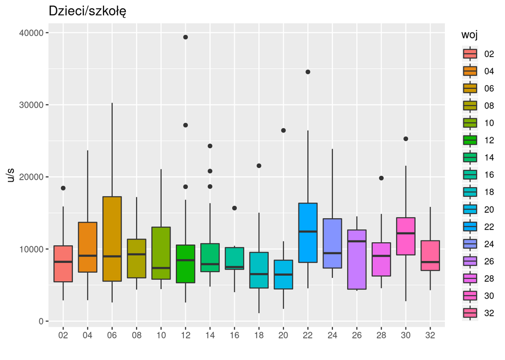

```r
ggplot(d, aes(x=woj, y=pppd, fill=woj)) +
geom_boxplot() + ylab("u/s") + xlab("") + ggtitle("Dzieci/szkołę");
```

Średnie UPP według województw:

```r
aggregate(pppd~woj, data=d, mean)
```

| woj | pppd |
| --- | --- |
| 02 | 8927 |
| 04 | 10571 |
| 06 | 11624 |
| 08 | 9461 |
| 10 | 9849 |
| 12 | 10517 |
| 14 | 9809 |
| 16 | 8607 |
| 18 | 7698 |
| 20 | 7564 |

[output cut: 6 more lines]

Histogram

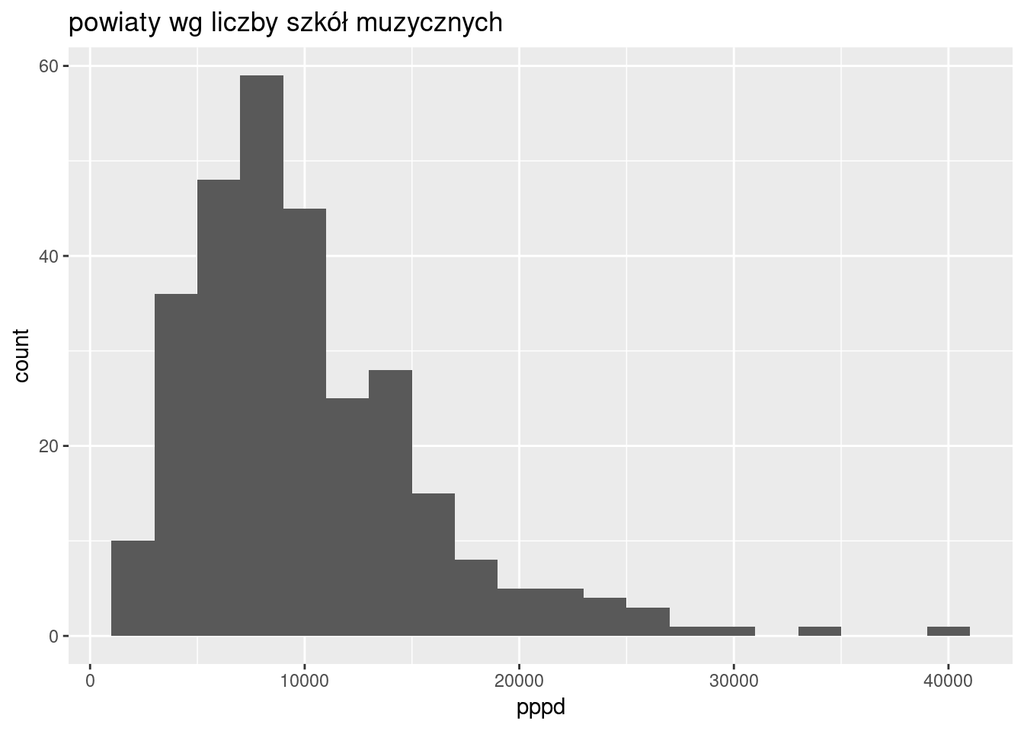

```r
ggplot(d, aes(x = pppd)) + geom_histogram(binwidth = 2000) +
ggtitle("powiaty wg liczby szkół muzycznych")
```

```r
s <- cut(d$pppd, dig.lab = 8, breaks = seq(0,40000, by=2000))

table(s)
```

```
## s
##      (0,2000]   (2000,4000]   (4000,6000]   (6000,8000]  (8000,10000]
##             2            15            52            61            44
## (10000,12000] (12000,14000] (14000,16000] (16000,18000] (18000,20000]
##            38            25            22            10             7
## (20000,22000] (22000,24000] (24000,26000] (26000,28000] (28000,30000]
##             7             4             2             3             0
## (30000,32000] (32000,34000] (34000,36000] (36000,38000] (38000,40000]
##             1             0             1             0             1
```

## Tylko miejskie

Tylko miasta na prawach powiatu (powiaty miejskie).

```r
d <- subset (do, typ == "m");
powiatyM <- nrow(d) # powinno być 66
pm.pop.total <- sum(d$ppp)
```

Liczba powiatów miejskich 66 (17.4%). Łączna liczba szkół 303. Średnia liczba osób w wieku przedprodukcyjnym w powiecie 31622.33 (łącznie 2087074 osób albo 30.16% całej populacji osób w wieku przedprodukcyjnym).

Rozkład liczby szkół w miastach na prawach powiatu:

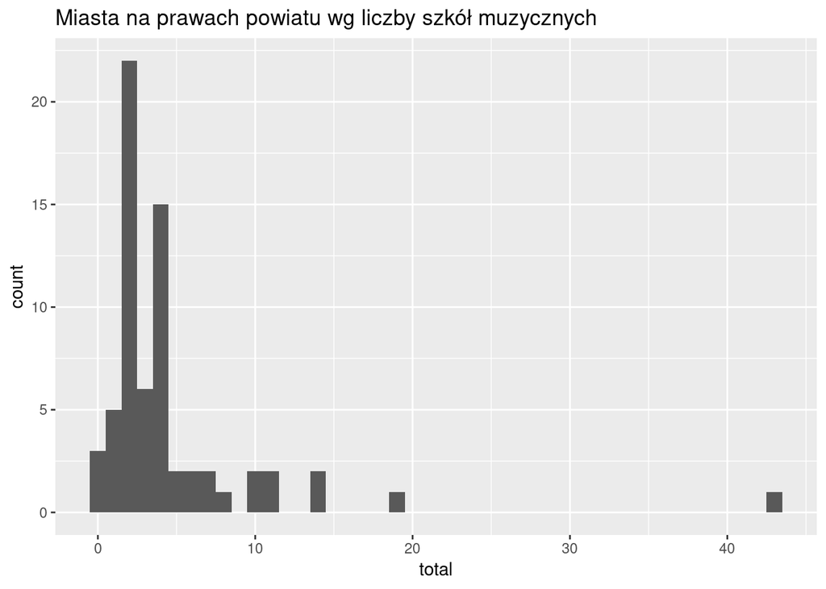

```r
ggplot(d, aes(x = total)) + geom_histogram(binwidth = 1) +
ggtitle("Miasta na prawach powiatu wg liczby szkół muzycznych")
```

```r
table(d$total)
```

```
##
##  0  1  2  3  4  5  6  7  8 10 11 14 19 43
##  3  5 22  6 15  2  2  2  1  2  2  2  1  1
```

Miasta w których nie ma żadnych szkół muzycznych (shame, ale są pewnie obok)

```r
s0 <- subset(d, total==0)
s0$nazwa
```

```
## [1] m.Mysłowice            m.Siemianowice Śląskie m.Świętochłowice
## 370 Levels: aleksandrowski augustowski bartoszycki ... żywiecki
```

UPP (tylko dla miast w których jest co najmniej jedna szkoła)

```r
d <- subset (d, total > 0);
pppDens <- d$ppp/d$total
d["pppd"] <- pppDens

order.pppd <- order(d$pppd)
list1 <- paste(d$pppd[order.pppd], d$nazwa[order.pppd], d$total[order.pppd])

head(list1, n=10) # najmniej uczniów na szkołę
```

```
##  [1] "1102.57142857143 m.Krosno 7"     "2489.75 m.Przemyśl 4"
##  [3] "2588.5 m.Biała Podlaska 4"       "2877 m.Jelenia Góra 4"
##  [5] "3268.66666666667 m.Chełm 3"      "3703.07142857143 m.Białystok 14"
##  [7] "3954.5 m.Nowy Sącz 4"            "4018.4 m.Opole 5"
##  [9] "4116.25 m.Legnica 4"             "4159.75 m.Wałbrzych 4"
```

```r
tail(list1, n=10) # najwięcej uczniów na szkołę
```

```
##  [1] "11063 m.Tychy 2"             "11122.875 m.Poznań 8"
##  [3] "12322 m.Zielona Góra 2"      "12611.5 m.Rybnik 2"
##  [5] "13297.6666666667 m.Gdynia 3" "13375 m.Bytom 2"
##  [7] "13925.5 m.Bydgoszcz 4"       "14658.5 m.Sosnowiec 2"
##  [9] "14868.5 m.Olsztyn 2"         "14914 m.Jaworzno 1"
```

średnia 7254.2 osób (mediana 6832 osób). Średnio na 1 szkołę w tej grupie powiatów przypada 6888.03 osób.

## Pozostałe powiaty

```r
d <- subset (do, typ == "p");
powiatyP <- nrow(d) # powinno być 66
pp.pop.total <- sum(d$ppp)
```

Liczba powiatów zwykłych 314 (82.63%). Łączna liczba szkół 420. Średnia liczba osób w wieku przedprodukcyjnym w powiecie 15393.56 (łącznie 4833578 osób albo 69.84% całej populacji osób w wieku przedprodukcyjnym).

Rozkład liczby szkół w powiatach “zwykłych”:

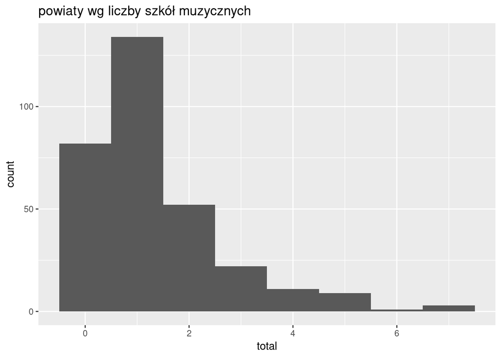

```r
ggplot(d, aes(x = total)) + geom_histogram(binwidth = 1) +
ggtitle("powiaty wg liczby szkół muzycznych")
```

```r
table(d$total)
```

```
##
##   0   1   2   3   4   5   6   7
##  82 134  52  22  11   9   1   3
```

Powiaty w których jest pięć i więcej szkół muzycznych

```r
s0 <- subset(d, total>4)
s0$nazwa
```

```
##  [1] toruński     zgierski     bocheński    krakowski    nowosądecki
##  [6] nowotarski   piaseczyński wołomiński   jarosławski  przeworski
## [11] rzeszowski   olsztyński   wrzesiński
## 370 Levels: aleksandrowski augustowski bartoszycki ... żywiecki
```

UPP (tylko dla miast w których jest co najmniej jedna szkoła)

```r
d <- subset (d, total > 0);
pppDens <- d$ppp/d$total
d["pppd"] <- pppDens

order.pppd <- order(d$pppd)
list1 <- paste(d$pppd[order.pppd], d$nazwa[order.pppd], d$total[order.pppd])

head(list1, n=10) # najmniej uczniów na szkołę
```

```
##  [1] "1702.5 sejneński 2"
##  [2] "2583.33333333333 proszowicki 3"
##  [3] "2767.75 słupecki 4"
##  [4] "2820.33333333333 grajewski 3"
##  [5] "2903.66666666667 golubsko-dobrzyński 3"
##  [6] "2935 przeworski 5"
##  [7] "3052 wrzesiński 5"
##  [8] "3325 moniecki 2"
##  [9] "3685.83333333333 bocheński 6"
## [10] "3832.5 strzeliński 2"
```

```r
tail(list1, n=10) # najwięcej uczniów na szkołę
```

```
##  [1] "23676 bydgoski 1"     "23878 będziński 1"    "24286 legionowski 1"
##  [4] "25283 koniński 1"     "26439 starogardzki 1" "26444 białostocki 1"
##  [7] "27175 oświęcimski 1"  "30266 lubelski 1"     "34558 kartuski 1"
## [10] "39378 tarnowski 1"
```

Średnia 10853.82 osób (mediana 9647.75 osób). Średnio na 1 szkołę w tej grupie powiatów 11508.52 osób.